# Algorithm benchmark in 1D

Niklas Hartung

2023-08-02

```r
library(kldest)
library(ggplot2)
set.seed(0)
```

In 1D, different KL divergence estimators are available, either based on kernel density estimation or on nearest-neighbour density estimation. Using different analytically tractable distributions and varying sample sizes, we evaluate different methods in terms of their accuracy and runtime.

## Specification of simulation scenario

### Distributions and KL-D

We investigate the following pairs of distributions, for which analytical KL divergence values are known:

- $\mathcal{N}(0,1)$ vs. $\mathcal{N}(1,2^2)$,
- $\mathcal{U}(1,2)$ vs. $\mathcal{U}(0,4)$,
- $\text{Exp}(1)$ vs. $\text{Exp}(12)$.

```r
p <- list(
    gaussian    = list(mu1 = 0, sigma1 = 1, mu2 = 1, sigma2 = 2^2),
    uniform     = list(a1 = 1, b1 = 2, a2 = 0, b2 = 4),
    exponential = list(lambda1 = 1, lambda2 = 1/12)
)
distributions <- list(
    gaussian = list(
        samples = function(n, m) {
            X <- rnorm(n, mean = p$gaussian$mu1, sd = sqrt(p$gaussian$sigma1))
            Y <- rnorm(m, mean = p$gaussian$mu2, sd = sqrt(p$gaussian$sigma2))
            list(X = X, Y = Y)
        },
        kld = do.call(kld_gaussian, p$gaussian)
    ),
    uniform = list(
        samples = function(n, m) {
            X <- runif(n, min = p$uniform$a1, max = p$uniform$b1)
            Y <- runif(m, min = p$uniform$a2, max = p$uniform$b2)
            list(X = X, Y = Y)
        },
        kld = do.call(kld_uniform, p$uniform)
    ),
    exponential = list(
        samples = function(n, m) {
            X <- rexp(n, rate = p$exponential$lambda1)
            Y <- rexp(m, rate = p$exponential$lambda2)
            list(X = X, Y = Y)
        },
        kld = do.call(kld_exponential, p$exponential)
    )
)
```

Analytical values for Kullback-Leibler divergences in test cases:

```r
vapply(distributions, function(x) x$kld, 1)
```

```
#>    gaussian     uniform exponential
#>   0.4431472   1.3862944   1.5682400
```

### Simulation scenarios

For each of the distributions specified above, samples of different sizes are drawn, with several replicates per distribution and sample size.

```r
samplesize <- 10^(2:4)
nRep       <- 25L

scenarios <- combinations(
    distribution = names(distributions),
    sample.size  = samplesize,
    replicate    = 1:nRep
)
```

### Algorithms

The following algorithms are considered:

```r
algorithms <- list(
    dens_int = function(X, Y) kld_est_kde1(X = X, Y = Y),
    dens_mc  = function(X, Y) kld_est_kde1(X = X, Y = Y, MC = TRUE),
    nn_1     = kld_est_1nn,
    nn_k_gen = function(X, Y) kld_est_gknn(X = X, Y = Y, warn.max.k = FALSE)
)
nAlgo   <- length(algorithms)
```

## Run the simulation study

```r
# allocating results matrices
nscenario  <- nrow(scenarios)
runtime <- kldiv1d <- matrix(nrow = nscenario,
                             ncol = nAlgo,
                             dimnames = list(NULL, names(algorithms)))

for (i in 1:nscenario) {

    dist <- scenarios$distribution[i]
    n    <- scenarios$sample.size[i]

    samples <- distributions[[dist]]$sample(n = n, m = n)
    X <- samples$X
    Y <- samples$Y

    # different algorithms are evaluated on the same samples
    for (j in 1:nAlgo) {
        algo <- algorithms[[j]]
        start_time <- Sys.time()
        kldiv1d[i,j] <- algo(X, Y)
        end_time <- Sys.time()
        runtime[i,j] <- end_time - start_time
    }
}
```

Post-processing: combine `scenarios`, `kldiv1d` and `runtime` into a single data frame

```r
tmp1 <- cbind(scenarios, kldiv1d) |> reshape2::melt(measure.vars = names(algorithms),
                                                    value.name = "kld",
                                                    variable.name = "algorithm")
tmp2 <- cbind(scenarios, runtime) |> reshape2::melt(measure.vars = names(algorithms),
                                                    value.name = "runtime",
                                                    variable.name = "algorithm")
results <- merge(tmp1,tmp2)
rm(tmp1,tmp2)
```

Convert to factor

```r
results$sample.size <- as.factor(results$sample.size)
```

## Results

### Accuracy of KL divergence estimators

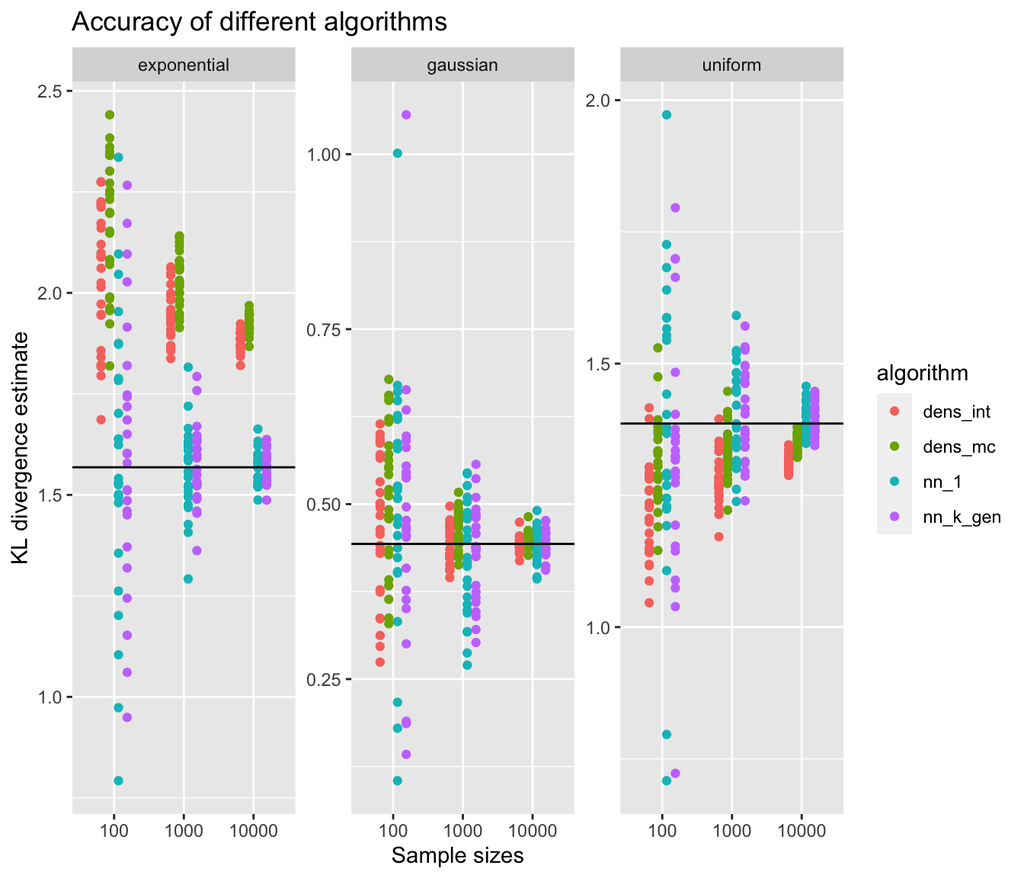

```r
ggplot2::ggplot(results, aes(x=sample.size, y=kld, color=algorithm)) +
    geom_jitter(position=position_dodge(.5)) +
    facet_wrap("distribution", scales = "free_y") +
    geom_hline(data = data.frame(distribution = names(distributions), kldtrue = vapply(distributions, function(x) x$kld,1)),
               aes(yintercept = kldtrue))+
    xlab("Sample sizes") + ylab("KL divergence estimate") + ggtitle("Accuracy of different algorithms")
```

$\Rightarrow$ all estimators converge towards the true KL divergence (black solid line). Kernel density-based estimators generally have a lower variance than nearest neighbour-based estimators, but show some finite sample bias, especially in the asymmetric exponential distribution. There is no difference between the 1-nearest neighbour and generalized k-nearest neighbour methods in terms of accuracy.

### Runtime of KL divergence estimators

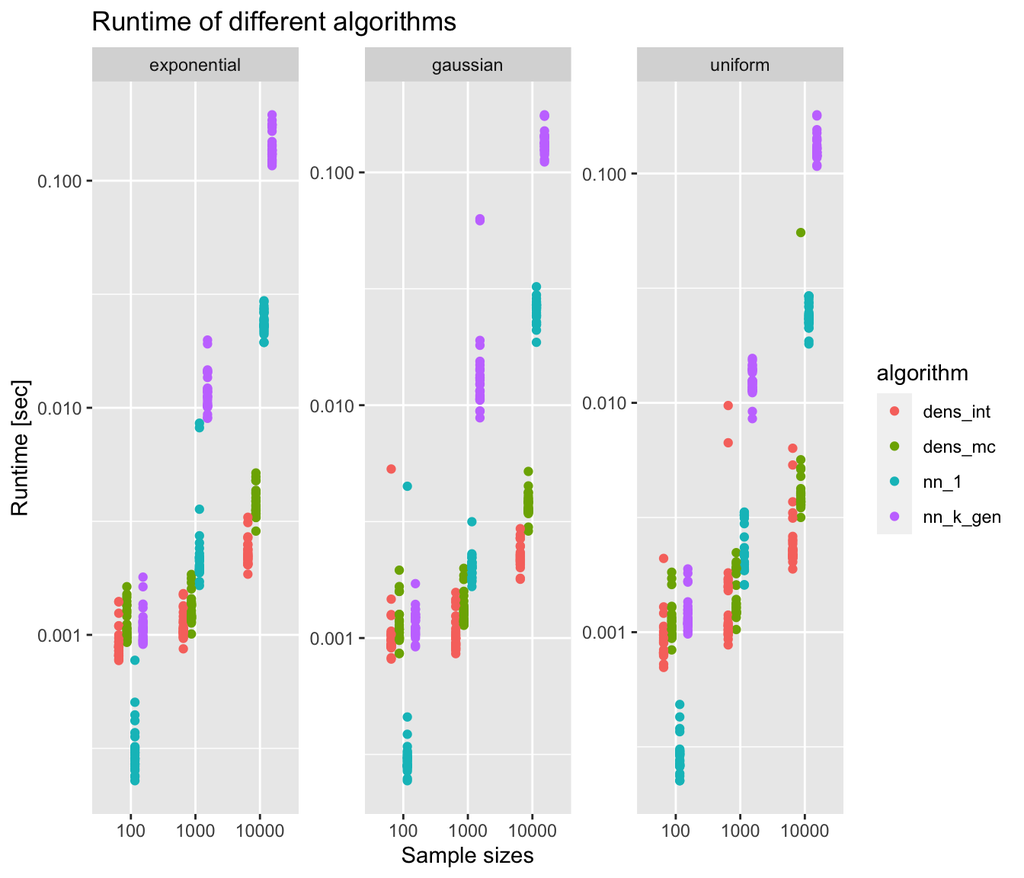

```r
ggplot2::ggplot(results, aes(x=sample.size, y=runtime, color=algorithm)) +
    scale_y_log10() +
    geom_jitter(position=position_dodge(.5)) +
    facet_wrap("distribution", scales = "free_y") +
    xlab("Sample sizes") + ylab("Runtime [sec]") + ggtitle("Runtime of different algorithms")
```